# Part II - Features of Delayed Flights

## by Corinne Sandor

## Investigation Overview

For my presentation, I focus on the just the influence of delay types and airline carriers on departure delay times.

I start by introducing the frequency at which certain delay types occur, then looking at the average delay time for each main delay type on a day to day basis. Afterwards, I do the same thing for airline carriers.

Since there seemed to be some trends with airline carrier delays, we wrap up this presentation by looking at the average departure delays for each airline carrier by delay type.

## Dataset Overview

This dataset contains information about 200,802 delayed flights from 1987 to 2008 (with the exception of the years 2001 & 2002). It contains 25 features, 11 of which we will be looking into:

- Departure Delay
- Airline Carrier Delay
- Weather Delay
- National Aviation System (NAS) Delay
- Security Delay
- Late Aircraft Delay
- Day of the Week
- Airline Carrier
- Origin Airport
- Destination Airport
- Delay Type (Carrier, Weather, NAS, Security, Late Aircraft)

## What are the most frequent reasons for departure delays?

Late aircrafts, airline carriers and national aviation system delays.

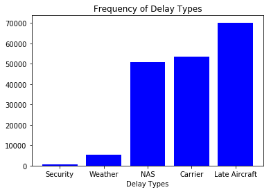

## How long does each delay type last on average?

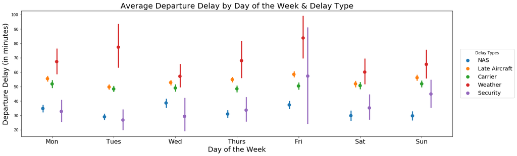

## What airlines are most often departing late?

Southwest Airlines (WN) has significantly more departure delays than any of the other airlines. In fact, it has 3x more departures delays than the airline with the next highest frequency, US Airways (US).

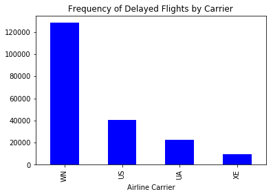

## What is the average delay time for each airline carrier?

From day to day,

- JSX Airlines (XE) and United Airlines(UA) tend to have higher average delay times, around 35-50 minutes, but are their lowest on Saturday and Sunday.
- Southwest Airlines (WN) and US Airways (US) tend to have lower average delay times, around 20-32 minutes.

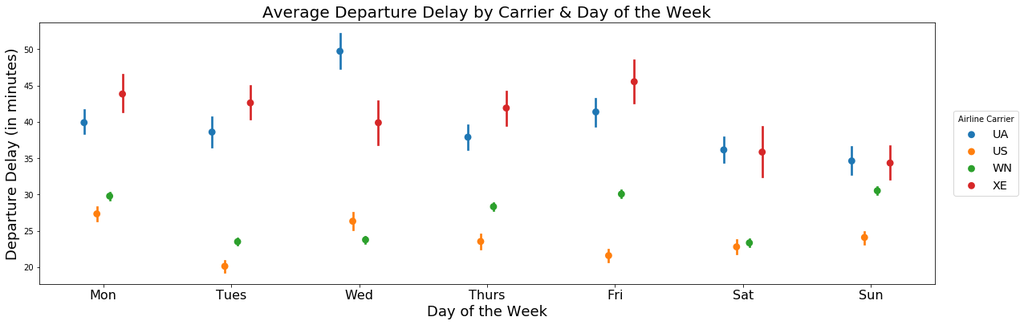

## Is there a difference in how long each delay type lasts for each carrier?

- As we saw before, late aircraft, carrier & weather delays typically are the longest delays. Southwest Airlines (WN) handles carrier delays a little better than the rest, with an average carrier delay time around 45 minutes.
- From day to day, US Airways (US) and Southwest Airlines (WN) have the shortest National Aviation System (NAS) delays on average, around 20-25 minutes.
- Security delays are usually around 35 minutes on average, except for US Airways (US). Their secuirty delays last around 80 minutes on average.

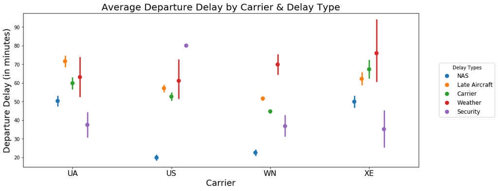